# Analysis of molecular variance of a worldwide collection of *Zymoseptoria tritici*

Based on Alice Feurtey’s code developed the 24.04.2023.

SNPs were sampled over the whole genome, while removing variants with more than 0.8 missing data, with more/less than 2 alleles, and with a minor allele count lower than 0.05. To further reduce the amount of redundant data, only SNPs further than 1kb apart were kept.

I show two plots that represent the number of samples I have used for the analysis.

```r
library(tidyverse)
library(pegas)
library(adegenet)
library(poppr)
library(knitr)
library(RColorBrewer)
library(hierfstat)
library(knitr)
```

```r
k8admixture<-read_csv("infotable.csv")


missing20rem<-c("Texas_1994_ST94TX_PF4a_1", "Tunisia_2008_ST08TN_33_1_2", "ST90ORE_a12_3B_13", "ST92YE_1")

isolateswrongstructure<-c("Ukraine_1995_ST95UR_F1c_1", "Israel_1992_ISZE2a_2", "Texas_1994_ST94TXPG7a_1", "Kenya_1994_STKE94ML1a", "Kenya_1994_STKE94MF1a")


metadata<-k8admixture  %>% filter(!(ID_genome_file %in% missing20rem)) %>% filter(!(ID_genome_file %in% isolateswrongstructure))
```

```r
project_dir="./"
vcf_file="thinnedplusindvrem.recode.vcf"
info <- VCFloci(paste0(project_dir, vcf_file))
```

```
## Scanning file ./thinnedplusindvrem.recode.vcf
##
 240.3963 / 240.3963 Mb
 240.3963 / 240.3963 Mb
## Done.
```

```r
info$ID <- c(1:nrow(info))

x <- read.vcf(paste0(project_dir, vcf_file), from = 1, to = nrow(info))
```

[output not shown]

[output cut: 228 more lines]

[output not shown]

```r
colnames(x) <- c(1:nrow(info))
g<-loci2genind(x, ploidy = 1)

print(paste0("I have worked on ", nrow(info), " SNPs."))
```

```
## [1] "I have worked on 28050 SNPs."
```

```r
for_strata = tibble(samples = rownames(x)) %>%
  left_join(metadata, by = c("samples" = "ID_genome_file")) %>%
  select(samples, Location, Adm_Cluster) %>% drop_na()

strata(g) <- for_strata


kable(t(table(strata(g, ~Adm_Cluster/Location, combine = FALSE))))
```

|  | Tunisia | Middle_East | Argentina_Uruguay | Australia | Europe | USA | Canada | Chile | Other |
| --- | --- | --- | --- | --- | --- | --- | --- | --- | --- |
| Annaba | 1 | 1 | 0 | 0 | 0 | 0 | 0 | 0 | 0 |
| Guelma | 1 | 0 | 0 | 0 | 0 | 0 | 0 | 0 | 0 |
| Argentina | 0 | 0 | 16 | 0 | 0 | 0 | 0 | 0 | 0 |
| Narrogin | 0 | 0 | 0 | 1 | 0 | 0 | 0 | 0 | 0 |
| Chapman | 0 | 0 | 0 | 1 | 0 | 0 | 0 | 0 | 0 |
| Badgingarra | 0 | 0 | 0 | 12 | 0 | 0 | 0 | 0 | 0 |
| Eschikon | 0 | 0 | 0 | 0 | 15 | 0 | 0 | 0 | 0 |
| California | 0 | 0 | 0 | 0 | 0 | 14 | 0 | 0 | 0 |
| Canada | 0 | 0 | 0 | 0 | 0 | 0 | 14 | 0 | 0 |
| Chile | 0 | 0 | 0 | 0 | 0 | 0 | 0 | 15 | 0 |
| Czech_Republic | 0 | 0 | 0 | 0 | 10 | 0 | 0 | 0 | 0 |
| Denmark | 0 | 0 | 0 | 0 | 15 | 0 | 0 | 0 | 0 |
| Ethiopia | 0 | 0 | 0 | 0 | 0 | 0 | 0 | 0 | 1 |
| Germany | 0 | 0 | 0 | 0 | 14 | 0 | 0 | 0 | 0 |
| Indiana | 0 | 0 | 0 | 0 | 0 | 13 | 0 | 0 | 1 |
| Mehran | 0 | 5 | 0 | 0 | 0 | 0 | 0 | 0 | 0 |
| Dezful | 0 | 7 | 0 | 0 | 0 | 0 | 0 | 0 | 1 |
| Israel | 0 | 37 | 0 | 0 | 0 | 0 | 0 | 0 | 0 |
| Missouri | 0 | 0 | 0 | 0 | 0 | 15 | 0 | 0 | 0 |
| Australia | 0 | 0 | 0 | 26 | 0 | 0 | 0 | 0 | 0 |
| Oregon | 0 | 0 | 0 | 0 | 0 | 74 | 0 | 0 | 0 |
| Uruguay | 0 | 0 | 15 | 0 | 0 | 0 | 0 | 0 | 0 |
| Berg_am_Irchel | 0 | 0 | 0 | 0 | 29 | 0 | 0 | 0 | 0 |
| Syria | 0 | 3 | 0 | 0 | 0 | 0 | 0 | 0 | 0 |
| Texas | 0 | 0 | 0 | 0 | 0 | 13 | 0 | 0 | 0 |
| Tunisia | 14 | 0 | 0 | 0 | 0 | 0 | 0 | 0 | 0 |
| Turkey | 1 | 1 | 0 | 0 | 0 | 0 | 0 | 0 | 3 |
| Ukraine | 0 | 0 | 0 | 0 | 0 | 0 | 0 | 0 | 4 |
| United_Kingdom | 0 | 0 | 0 | 0 | 16 | 0 | 0 | 0 | 0 |
| Yemen | 0 | 2 | 0 | 0 | 0 | 0 | 0 | 0 | 0 |

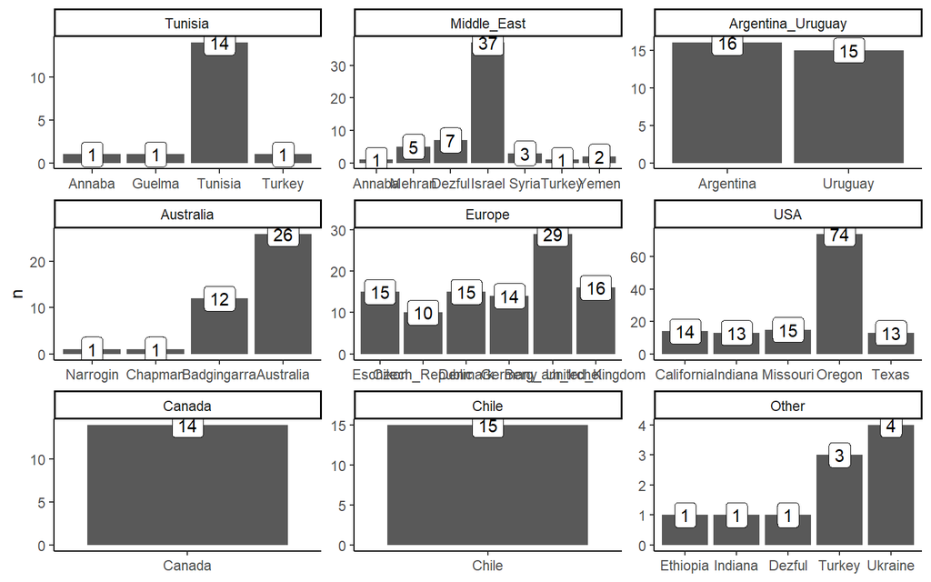

```r
count(strata(g, ~Adm_Cluster/Location, combine = FALSE), Adm_Cluster, Location) %>%
  ggplot(aes(x = Location, y = n, label = n)) +
  geom_bar(stat = "identity") +
  geom_label() +
  theme_classic() +
  facet_wrap(vars(Adm_Cluster), scales = "free") +
  theme(axis.title.x = element_blank())
```

# 1 AMOVA

AMOVA stands for Analysis of MOlecular VAriance and is a method to detect population differentiation utilizing molecular markers (Excoffier, Smouse, and Quattro 1992). From the paper, “This analysis of molecular variance (AMOVA) produces estimates of variance components and F-statistic analogs, designated here as phi-statistics, reflecting the correlation of haplotypic diversity at different levels of hierarchical subdivision.”

To create the AMOVA, we need to create a hierarchical structure (strata) that indicate the different level of structure in the sampling. Here I have chosen “Locations” which are fields/countries and “Adm_Cluster” which are genetic clusters. Code inspired by https://grunwaldlab.github.io/Population_Genetics_in_R/AMOVA.html

```r
amova_test <- poppr.amova(g, ~Adm_Cluster/Location)
```

```
##
##  No missing values detected.
```

```r
amova_test
```

```
## $call
## ade4::amova(samples = xtab, distances = xdist, structures = xstruct)
##
## $results
##                                     Df    Sum Sq   Mean Sq
## Between Adm_Cluster                  8  760302.2 95037.769
## Between samples Within Adm_Cluster  26  317674.0 12218.230
## Within samples                     376 2763396.9  7349.460
## Total                              410 3841373.1  9369.203
##
## $componentsofcovariance
##                                                    Sigma          %
## Variations  Between Adm_Cluster                1888.3737  19.330803
## Variations  Between samples Within Adm_Cluster  530.8948   5.434636
## Variations  Within samples                     7349.4599  75.234561
## Total variations                               9768.7285 100.000000
##
## $statphi
##                               Phi
## Phi-samples-total       0.2476544
## Phi-samples-Adm_Cluster 0.0673694
## Phi-Adm_Cluster-total   0.1933080
```

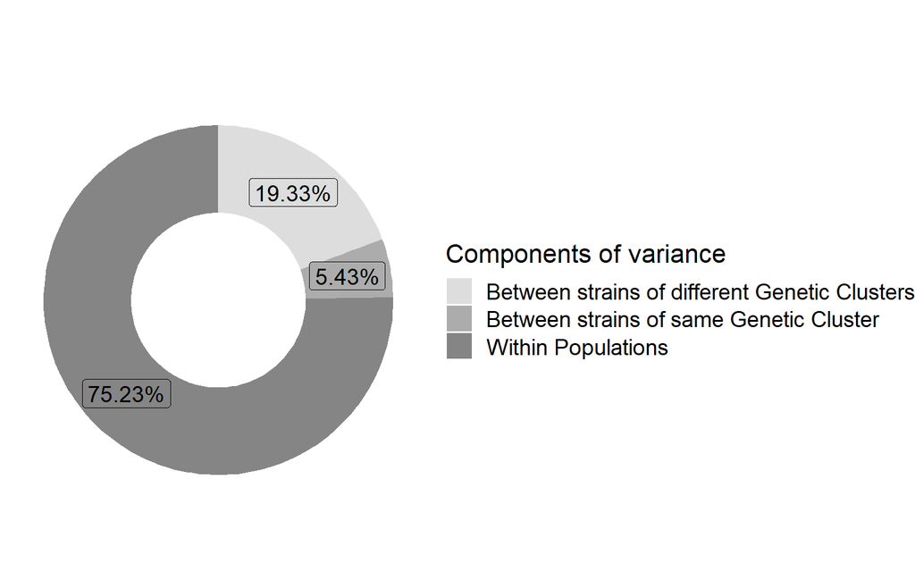

```r
# Create test data.
data <- as_tibble(amova_test$componentsofcovariance, rownames = "Comparison") %>%
  select(Comparison, Percent = `%`) %>%
  filter(Comparison != "Total variations")

# Compute percentages
data$fraction <- data$Percent / sum(data$Percent)

# Compute the cumulative percentages (top of each rectangle)
data$ymax <- cumsum(data$fraction)

# Compute the bottom of each rectangle
data$ymin <- c(0, head(data$ymax, n=-1))

# Compute label position
data$labelPosition <- (data$ymax + data$ymin) / 2

# Compute a good label
data$label  <- paste0(round(data$Percent, 2), "%")
#<- paste0(data$category, "\n value: ", data$count)

legend_title<-"Components of variance"

# Make the plot
ggplot(data, aes(ymax=ymax, ymin=ymin, xmax=4, xmin=3, fill=Comparison)) +
  geom_rect() +
  geom_label( x=3.5, aes(y=labelPosition, label=label), size=5, show.legend = FALSE) +
  scale_fill_manual(legend_title,values=c("#dddddd", "#acacac", "#858585"),labels=c('Between strains of different Genetic Clusters', 'Between strains of same Genetic Cluster', 'Within Populations')) +
  coord_polar(theta="y") +
  xlim(c(2, 4)) +
  theme_void() +
  labs(title = "") + theme(legend.text=element_text(size=14), legend.title=element_text(size=16))
```

```r
Aeutsignif   <- randtest(amova_test, nrepet = 999)
Aeutsignif #all significant, first less then greater and greater.
```

[output not shown]

# References

Excoffier, L., P. E. Smouse, and J. M. Quattro. 1992. “Analysis of Molecular Variance Inferred from Metric Distances Among DNA Haplotypes: Application to Human Mitochondrial DNA Restriction Data.” *Genetics* 131 (2): 479–91. https://www.ncbi.nlm.nih.gov/pmc/articles/PMC1205020/.